# Tre enkla sätt att skapa automatiserade rapporter baserade på statistik från SCB

Author

Magnus Forslund, Visualiseringsgruppen

# Spara tid genom automatisk uppdatering

Automatiserad hämtning från SCB:s publika databas för att visualisera de löpande befolkningsförändringarna under året kan göras på flera sätt. Vi kommer här att beskriva tre olika sätt, de två första har mycket gemensamt i sättet att hämta data, men använder olika program för den slutliga presentationen (**Excel** respektive **Power BI**). Det tredje sättet är kodbaserat och innebär att både hämta och visualisera data i **R**. Tanken är att detta kan fungera som ett smörgåsbord för den intresserade, där metod väljs efter organisationens förutsättningar och de egna förkunskaperna.

Alla tre angreppssätten går att utveckla nästan hur mycket som helst och är möjliga att anpassa utifrån egna behov samt kompetens och ambition inom visualiseringslösningar. Val av färger, typsnitt osv. är ofta kopplat till organisationens grafiska profil därför läggs ingen rekommendation från visualiseringsgruppen runt dessa delar.

I exemplet används SCB:s tabell över de löpande befolkningsförändringarna men det går självklart att utveckla och använda lösningarna till alla tabeller i SCB:s statistikdatabas eller i valfri PX-webb-tabell hos kommuner och regioner som använder PX-webb-verktyget för publicering. Det går alltså relativt smidigt att på egen hand bygga upp ett system med tabeller från statistikdatabasen som lätt kan uppdateras när ny statistik publicerats.

# Tre olika exempel

Alla tre sätt kräver viss förkunskap. För de två första behövs grundläggande kunskaper i Excel och gärna en viss vana vid pivottabeller. Både Excel och Power BI är Microsoftprodukter, vilket kan utgöra en begränsning, erfarenheten är dock att de flesta ksp-medlemmar har tillgång till framförallt Excel. Power BI går att ladda ner kostnadsfritt, med begränsningen att det inte går att göra med en privat e-postadress (t.ex. gmail eller hotmail).

Att använda R kräver andra förkunskaper. Även om scriptet gör det mesta själv behövs en grundläggande förståelse för hur koden fungerar och var de egna tillämpningarna ska skrivas in. R och RStudio är gratis för nerladdning och numera borde det finnas en vana hos de flesta IT-avdelningar att hantera den här typen av open sourceprogram.

Vår förhoppning är att någon av metoderna ska passa just dig och underlätta det fortsatta arbetet och skapa en nyfikenhet för att fortsätta arbeta med automatisering på egen hand. Som ni säkert förstår har vi små möjligeter att lämna ytterligare support vid frågeställningar som kan dyka upp under resans gång, framförallt sådant som är kopplat till de olika programvarorna.

## Automatisk hämtning med hjälp av Power query

**Power query** är ett verktyg som finns inbyggt i både Excel och Power BI. Det används för att koppla upp sig mot olika datakällor, alltifrån publika databaser som SCB och Kolada till lokala filer i olika format (Excel, csv, pdf mm). Förutom att hämta data så är power query användbart för att strukturera data, lägga till kolumner eller göra återkommande beräkningar. Alla transformeringar som görs av den ursprungliga datat sparas i separata steg i modellen, som därför passar bra för återkommande och automatiserade hämtningar. När ny data finns tillgänglig behöver filen bara uppdateras för att den nya datan ska läggas till i de tabeller och diagram som du har skapat initialt.

Eftersom Power query läser in datat i sin modell kan det finnas anledning att inte läsa in alltför stora datamängder. Metoden som beskrivs här begränsas även av hur stora datauttag som är möjliga att göra ifrån SCB:s databas. Ett enkelt sätt att komma förbi den problematiken är att dela upp uttagen, det går bra att använda flera querys i samma dokument (oavsett om det är Excel eller Power BI). Frågorna kan sedan antingen hanteras separat eller slås ihop i din lokala miljö.

### Hämta tabellen från SCB

Statistikkälla: [Befolkningsstatistik efter region och kön. Månad 2000M01 -](https://www.statistikdatabasen.scb.se/pxweb/sv/ssd/START__BE__BE0101__BE0101G/ManadBefStatRegion/)

Maximalt antal celler i tabelluttag från SCB är 150 000. Med den begränsningen går det att hämta alla typer av förändringar för kvinnor och män varje enskild månad för alla kommuner i landet. I exemplet nedan kommer jag att hämta uppgifter för tio kommuner i Västmanlands län och då räcker utrymmet för att hämta alla månader sedan januari år 2000. Här är det helt enkelt dina egna behov som bestämmer hur du utformar tabellen och eventuellt delar upp den i flera uttag.

Steg 1. Ta fram den tabell du behöver i SCB:s databas. När du valt önskade värden, klicka på knappen “Fortsätt”.

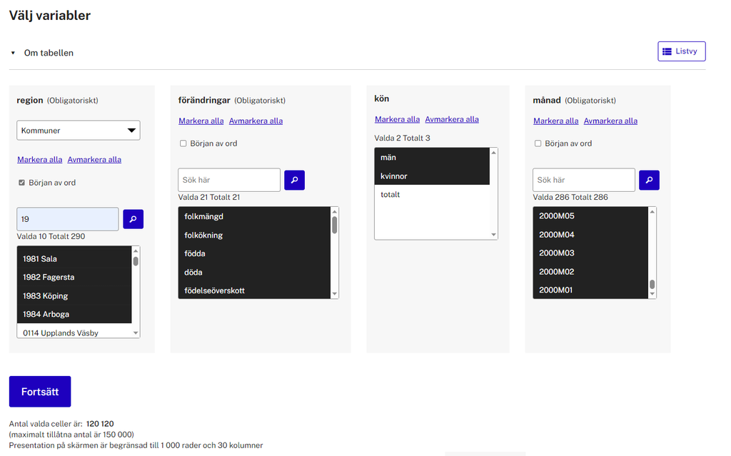

Steg 2. Välj alternativet “Pivotera manuellt” för att strukturera om tabellen så att den är bättre förberedd för Power query. I den utökade dialogrutan till höger på skärmen väljer du att flytta variabeln “månad” från kolumner till rader. Du kommer nu att ha samtliga värden i en och samma kolumn. På det här sättet undviks eventuella problem i uppdateringen när det tillkommer nya månader.

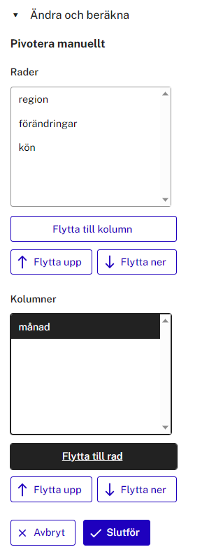

Steg 3. Välj “Spara sökningen” och alternativet “Uppdatera sökningen med rullande starttidpunkt och oförändrat antal tidsperioder”. Detta val kommer alltid att generera lika många celler i uttaget som första gången du gör det och du behöver alltså inte oroa dig för att slå i taket.

Därefter ska du välja hur resultatet ska visas under “Visa resultatet som (obligatorisk)”. Här kan flera alternativ fungera men jag brukar välja “Semikolonavgränsad utan rubrik” för att bara få med själva datat.

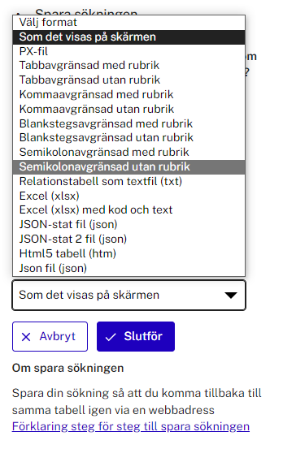

I dialogrutan “Spara sökningen” får du fram en länk som ser ut så här:  
(Länken i sig skapar en ny, uppdaterad csv-fil för nedladdning varje gång den används så det kan sägas vara den allra enklaste formen av automatiserat uttag.)

https://www.statistikdatabasen.scb.se/sq/143464

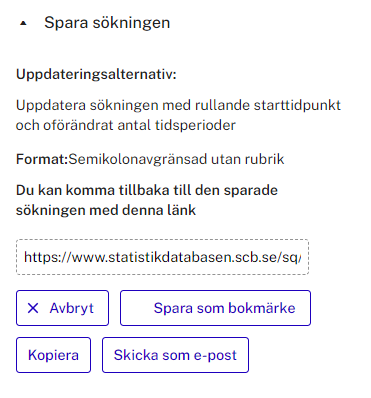

Kopiera länken, den ska nu användas i Power Query. Fortsättningen delas upp i två spår, ett för Excel och ett för Power BI, även om metoden är den samma.

### Excel

Steg 4. Öppna ett nytt Exceldokument och gå till fliken “Data” och välj “Hämta data - Från webb”. Klistra in den kopierade länken i rutan URL (det räcker med att vara i “grundläggande läge”). Här kan du sedan antingen välja att läsa in data direkt eller välja “Transformera data”. Den här tabellen är relativt enkel och färdig så den fungerar att läsa in direkt. Resultatet blir en ny flik i dokumentet med den sparade sökningen.

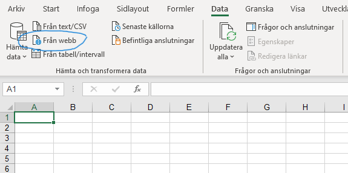

Förhandsgranskning av innehållet i frågan:

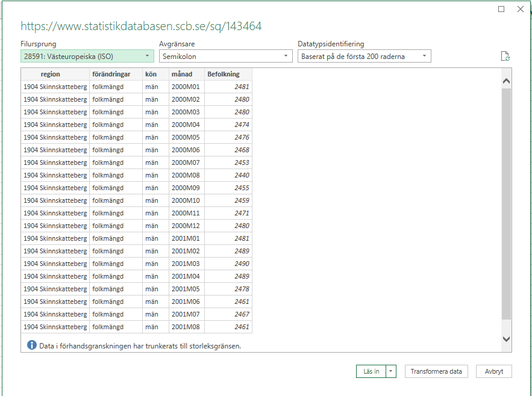

Resultatet i Excel efter inläsning:

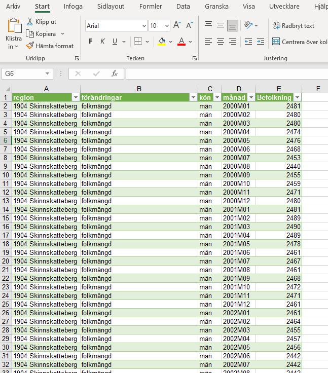

Steg 5. Gör en pivottabell baserad på den hämtade tabellen så kan du sedan utforma en anpassad redovisning av befolkningsförändringarna. I exemplet nedan har jag lagt alla typer av förändringar i en tabell men här går det såklart att göra på en rad olika sätt, t.ex. placera födda, döda och födelsenetto i ett och samma diagram och lägga till 12 månaders glidande medelvärde.

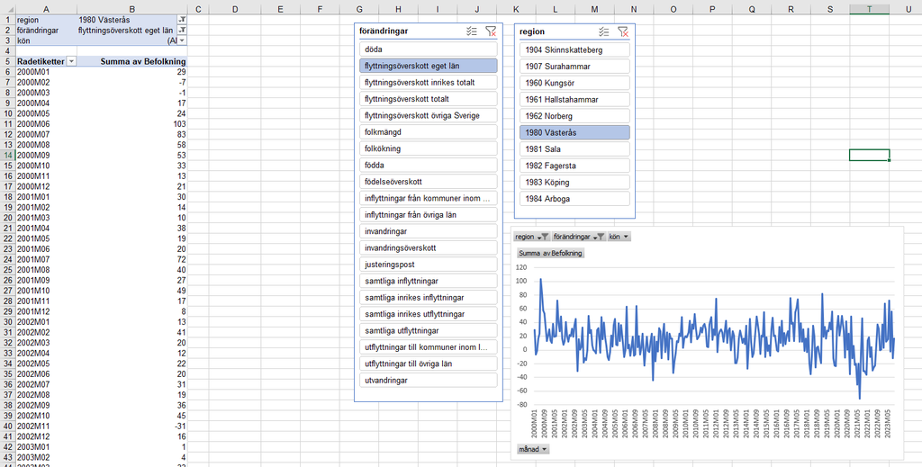

Steg 6 (uppdatering). För att uppdatera tabellen med ny data kan du antingen välja “Uppdatera alla” under fliken Data eller högerklicka i datatabellen och välja “Uppdatera”. Den sparade frågan körs då mot SCB:s databas och innehållet uppdateras. Utifrån det val jag gjorde tidigare så kommer den senaste tillgängliga månaden att läggas till i tabellen och den första befintliga månaden att tas bort.

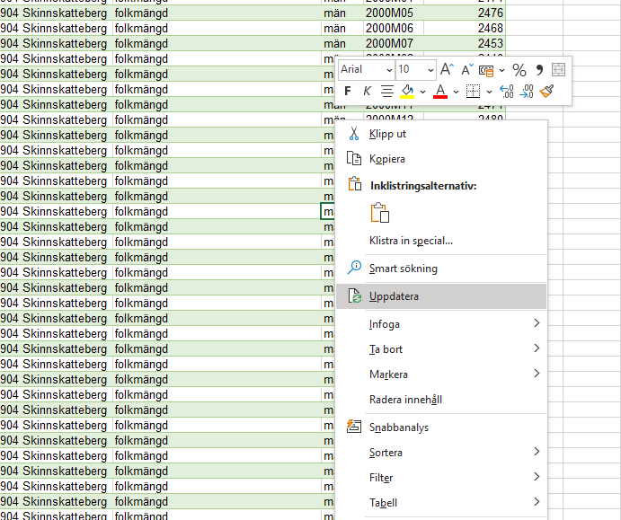

### Power BI

*Steg 1-3 som tidigare beskrivet.*

Steg 4. Öppna Power BI och välj Hämta data - Webben. Klistra in den kopierade länken i rutan URL. Här kan du antingen välja att läsa in data direkt eller först välja “Transformera data”. I det här exemplet väljer jag att transformera data.

Detta val öppnar ett separat fönster med egna menyer och flikar för olika åtgärder. Varje enskilt steg (de ändringar eller tillämpningar du gör i läget “Transformera data”) sparas även i fönstret “Frågeinställningar” till höger på skärmen.

[figure not shown]

De förändringar jag gör är att:

1) dela upp kolumnen region i två kolumner, en för kommunkod och en för kommunnamnet. Det gör jag bara för att det blir snyggare i den slutliga visualiseringen.

2) skapa en ny anpassad kolumn, baserad på den befintliga kolumnen månad. Jag gör detta genom kommandot “Kolumn från exempel” under fliken Lägg till kolumn. I det här fallet räcker det med att manuellt skriva in ett datum (YYYY-MM-DD) för de två första raderna så förstår systemet vad du vill göra och fyller i resterande celler automatiskt. Ange sedan datum som format för kolumnen (“Datatyp” under fliken Transformera).

Det finns flera olika sätt att skapa nya, egna kolumner i Power query. Allt från beräknade kolumner till den som används i exemplet, där systemet “känner av” vad jag vill göra, baserat på informationen i den första, befintliga kolumnen, där texten “2000M01” omvandlas till ett datum 2000-01-28. I det här fallet räcker det med två exempel för att systemet ska förstå hela den logiska kedjan.

Välj “Stäng och använd” under Startfliken för att läsa in den transformerade tabellen. Den ser nu ut så här:

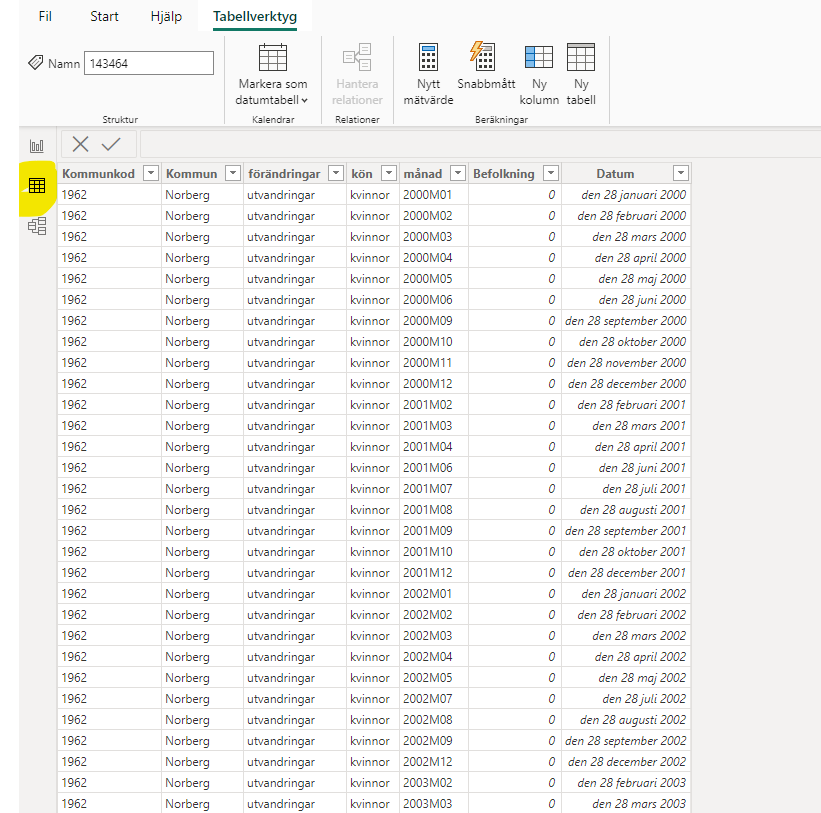

Steg 5. Gå till rapportvyn och skapa ett linjediagram. I och med att jag i transformeringen skapade en datumkolumn (inkl. datumhierarki) finns möjlighet att dela upp innehållet på ett mer pedagogiskt sätt än vad som är möjligt med hjälp av den ursprungliga kolumnen för månad. Här vill jag t.ex. ha månad på x-axeln och år som förklaring. Y-axeln är värdena som ska visas (“Befolkning”).

Datumhierarkin kan användas i sin helhet eller med valfri del. Hela hierarkin behöver alltså inte ligga i samma fält i visualiseringarna.

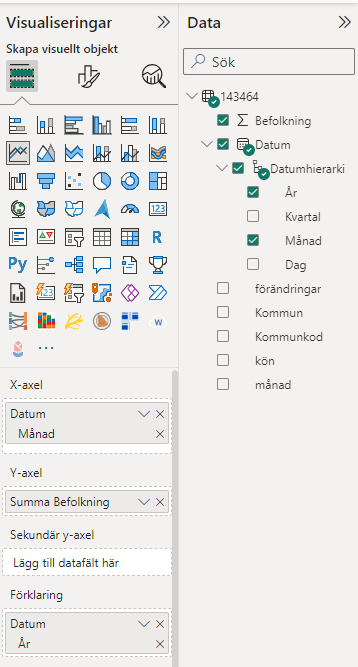

För att det ska bli ett begripligt diagram skapar jag ett utsnitt (filter) för att visa endast en komponent av befolkningsförändringen åt gången. Jag skapar även ett utsnitt för kommun. Utsnitten skiljer sig åt från varandra, under “förändringar” måste det vara en (och endast en) variabel som väljs. Under “kommun” kan alla eller en valfri grupp väljas eftersom den bakomliggande tabellen endast består av antalsvärden. Om ingen kommun väljs visas således värdet för hela länet.

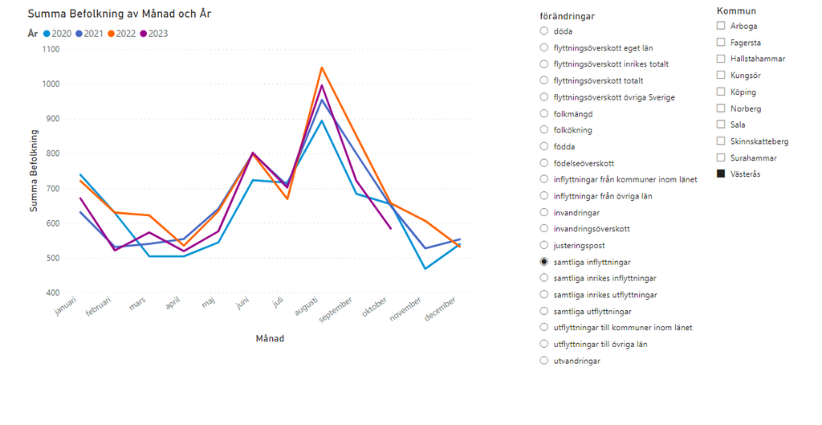

Steg 7. I Power BI kan du skapa beräknade *snabbmått* som är baserade på innehållet i tabellen. Finessen här är att du skapar ett snabbmått en gång som sedan kan användas i de filtreringar och anpassningar som redan gjorts. Eftersom vi har en datumkolumn med datumhierarki finns det flera olika beräkningar som kan göras. Jag ska göra en beräkning för summan hittills under året.

[figure not shown]

Genom att välja kolumnen “Datum” som input för beräkningen och klicka på Lägg till skapas en ny variabel “Befolkning YTD” som är baserad på den befintliga kolumnen “Befolkning” i tabellen.

[figure not shown]

Genom att byta ut variabeln på y-axeln till det nya snabbmåttet Befolkning YTD får vi istället följande diagram, där månaderna ackumuleras under året.

I diagrammet har jag under “Filter” uteslutit punkterna för november och december 2023 eftersom de saknar data. I grundläget får de samma värde som oktober (senast tillgängliga data vid tidpunkten för uttaget), vilket blir missvisande. Tacksam för tips om någon har en smidigare lösning på detta!

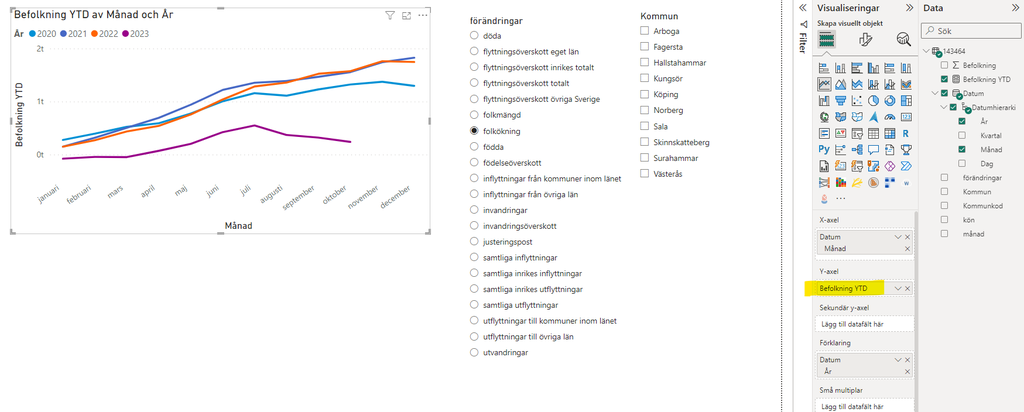

Steg 8. Välj dina egna färger och formuleringar för diagramrubriker etc.

Steg 9 (uppdatering). För att uppdatera tabellen med ny data kan du antingen klicka på knappen “Uppdatera” under fliken Start alternativt klicka i de tre punkterna för fler alternativ för datatabellen i sidofönstret Data och välja “Uppdatera data”. Den sparade frågan körs då mot SCB:s databas och innehållet uppdateras.

## Med hjälp av R

Thomas Lassi i Helsingborgs stad har tagit fram ett R-script för att kunna hämta hem data för valfri kommun och visualisera det på ungefär samma sätt som i exemplen ovan. Scriptet genererar ett diagram för varje typ av befolkningsförändring, här ett exempel på den ackumulerade folkökningen i Västerås.

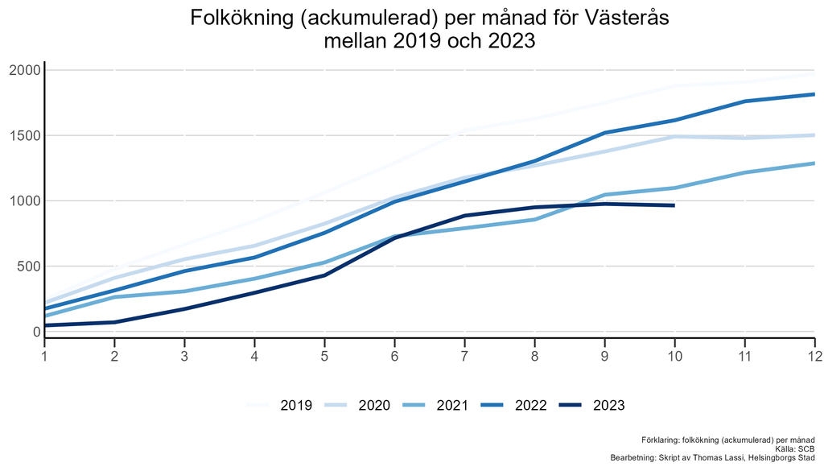

Scriptet finns tillgängligt via Thomas sida på Github, se länk nedan under “Exempel på rapporter”. Där finns även en kort instruktion över hur det fungerar.

I R kommer vi förbi begränsningen med antal celler i tabelluttag genom API-anrop och genom att exempelvis använda det färdiga px-paketet som finns framtaget för R.

## Exempel på rapporter

[Befolkningsförändringar under året i Västmanlands kommuner](https://app.powerbi.com/view?r=eyJrIjoiYTVkZjg0MjktODgzOC00MWJmLWE1NTctZmE2YWY5YjgyNjc0IiwidCI6ImMyNzg4N2VkLTBmNGQtNGZmYS04OGFmLTIzOWNmOTg4NDE3OCIsImMiOjh9)

[Folkmängdens utveckling (Göteborgs stad)](https://app.powerbi.com/view?r=eyJrIjoiM2QzZTc3YTUtZTAyMS00YTBjLWI0MWUtZmU4MzM2YTI5Y2EzIiwidCI6ImRmNDU1Y2M1LTBjOTEtNDgyNS05MTY4LTdmOWRlN2QyOGEwNSIsImMiOjh9)

[Befolkningsförändringar SCB (Github)](https://github.com/Lemeard/Skript/blob/main/befolkningsforandringar_SCB_API.R)